# Vignette Title

At this point R will need to be open and running, either R GUI or R Studio will suffice. I’ve placed an R installer (R-3.3.1-win.exe) into the U drive folder above (U:_2016_2017Exports) in the event any computer does not already have R installed. However, the user will need administrator rights to install it on any computer.

[figure not shown]

R open.

[figure not shown]

Copied and Pasted Code.

Then, you simply copy and paste or type in ‘redcap.importer(arm=2)’ and inside of U:_2016_2017Exports you will see ‘HIVE study import update.csv’, the final product. In the event that the user needs to enter data for arms 1 (HIVE re-enrollees) or arm 3 (pediatric clinic HIVE), simply change the function to ‘redcap.importer(arm=1)’ or ‘redcap.importer(arm=3)’, respectively. The default is arm 2, and so if a user enters into the R command line ‘redcap.importer()’ without ‘arm’ specified, then arm 2 is assumed.

[figure not shown]

After running the program.

The next step is to simply upload ‘HIVE study import update.csv’ to REDCap by navigating to the ‘HIVE Study’ project in REDCap production mode and accessing the ‘Data import Tool’

[figure not shown]

HIVE Study dashboard.

Once accessing the Data Import Tool module, scroll to the bottom of the page to see a spot to ‘Choose File’ and ‘Upload File’

[figure not shown]

Uploading to HIVE Study.

Next, click ‘Choose File’ and navigate to U:_2016_2017Exportsstudy import update.csv then click ‘Upload File’. You will then see the following:

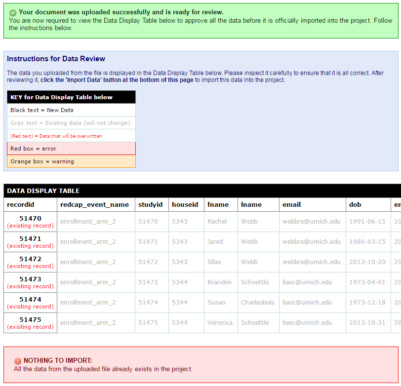

Uploading to HIVE Study (cont.)

In this example all the data was already uploaded so no new data could be uploaded. When you are uploading new data the REDCap web page will have a button near the bottom to approve of the upload: data will not be uploaded until you hit that button.

Then you are done.

# In Summary

In summary there are three major steps:

1. Download (export) the data from REDCap:HIVE Enrollment
   1. place file into the U drive and copy it and rename it to ‘HIVE enrollment export update’
2. Open R and run ‘redcap.importer()’
3. Open REDCap:HIVE Study and import ‘HIVE study import update.csv’ to REDCap